# BLAST Example

Alexander Kaier, Christoph Richard

2025-12-04

# 1 Introduction

The last part of the practical course was concerned with the simulation of alignment results and the statistical distribution of the resulting alignment scores. We have shown visually that the scores are approximately Gumbel-distributed with parameters $a_m$ and $b$, which were derived from the alignment parameters $\lambda$ and $K$. This time, we will conduct and actual BLAST search, using a sequence of unknown origin and the NCBI database, we have downloaded earlier. Afterwards, we will analyze the BLAST results.

# 2 BLAST search

Since we already have the database in our DATA directory, we can check out its structure and content in bash:

```bash
# Print the first 50 lines of the file
head -n 50 uniprot_sprot.fasta
# This is a neat trick to get the number of sequences, since each sequence has a header that starts with ">"
grep -c ">" uniprot_sprot.fasta
```

## 2.1 The query sequence

Now we need a FASTA file containing a single sequence to blast against the database. The sequence we will use today is called *query_sequence.fasta* and can be found on StudOn. Our aim for now is to find out what species the protein sequence comes from and analyse the output. Later on, we use the BLAST output to conduct multiple sequence alignment (MSA) and construct a phylogenetic tree.

```bash
# Show the whole sequence
cat query_sequence.fasta
```

## 2.2 Building a database

In order to actually blast something, we need to construct a blast database from the protein sequence database we downloaded earlier. Fortunately, there is a function for that:

```bash
makeblastdb -in uniprot_sprot.fasta -input_type fasta -title uniprot -dbtype prot
```

Where there was once only the `uniprot_sprot.fasta` file in your directory, now you can also find the following files that are necessary for the BLAST search:

- `uniprot_sprot.pdb` *Protein database* contains information about the sequences themselves, e.g. their IDs, description and sequence data in compressed format.
- `uniprot_sprot.phr` *Protein Header* contains the header and positional information of the sequences
- `uniprot_sprot.pin` *Protein index* contains indexing information, such as pointers to the `.pdb` and `.phr` file that allow BLAST to rapidly access regions of the database
- `uniprot_sprot.pot` *Protein Offset Table* stores information about the offsets. This helps BLAST efficiently map sequences in the database for faster querying.
- `uniprot_sprot.psq` *Protein Sequence* contains the actual sequence information used by the BLAST algorithm in binary format.
- `uniprot_sprot.ptf` *Protein Taxonomy File* contains taxonomy IDs and hierarchical relationships. This is used for taxonomic filtering or reporting.
- `uniprot_sprot.pto` *Protein Taxonomy Offset* contains offset pointers to the data in the `.ptf` file. This allows rapid retrieval of taxonomy information of sequences.

## 2.3 BLAST

[figure not shown]

Rambo BLASTING his way through the enemy lines. We will also BLAST something today, but in a more civilized manner. Source: https://www.joblo.com/lists-top-10-rambo-kills/

Now we are already set up to actually BLAST our query sequence against the uniprot database. We do this using the following line of bash code:

```bash
blastp -query query_sequence.fasta -db uniprot_sprot.fasta > query_seq_blast.blast
```

We use the `blastp` program to BLAST a protein sequence against a protein sequence database. As query sequence (`-query`) we use our *query_sequence.fasta* file and for the database (`-db`) we use the *uniprot_sprot.fasta* file. The output of the BLAST search is piped into the `query_seq_blast.blast` file using `>`.

Below, you can see the first 50 lines of this output file:

```
BLASTP 2.12.0+


Reference: Stephen F. Altschul, Thomas L. Madden, Alejandro A.
Schaffer, Jinghui Zhang, Zheng Zhang, Webb Miller, and David J.
Lipman (1997), "Gapped BLAST and PSI-BLAST: a new generation of
protein database search programs", Nucleic Acids Res. 25:3389-3402.


Reference for composition-based statistics: Alejandro A. Schaffer,
L. Aravind, Thomas L. Madden, Sergei Shavirin, John L. Spouge, Yuri
I. Wolf, Eugene V. Koonin, and Stephen F. Altschul (2001),
"Improving the accuracy of PSI-BLAST protein database searches with
composition-based statistics and other refinements", Nucleic Acids
Res. 29:2994-3005.



Database: uniprot
           572,619 sequences; 207,431,389 total letters



Query= 11111111.1 unknown_protein [Unknown species]

Length=1863
                                                                      Score     E
Sequences producing significant alignments:                          (Bits)  Value

sp|P38398|BRCA1_HUMAN Breast cancer type 1 susceptibility protein...  3844    0.0
sp|Q9GKK8|BRCA1_PANTR Breast cancer type 1 susceptibility protein...  3773    0.0
sp|Q6J6I8|BRCA1_GORGO Breast cancer type 1 susceptibility protein...  3757    0.0
sp|Q6J6J0|BRCA1_PONPY Breast cancer type 1 susceptibility protein...  3699    0.0
sp|Q6J6I9|BRCA1_MACMU Breast cancer type 1 susceptibility protein...  3504    0.0
sp|Q95153|BRCA1_CANLF Breast cancer type 1 susceptibility protein...  2667    0.0
sp|Q864U1|BRCA1_BOVIN Breast cancer type 1 susceptibility protein...  2587    0.0
sp|O54952|BRCA1_RAT Breast cancer type 1 susceptibility protein h...  1849    0.0
sp|P48754|BRCA1_MOUSE Breast cancer type 1 susceptibility protein...  1845    0.0
sp|F4I443|BARD1_ARATH BRCA1-associated RING domain protein 1 OS=A...  89.0    3e-16
sp|Q8RXD4|BRCA1_ARATH Protein BREAST CANCER SUSCEPTIBILITY 1 homo...  81.6    5e-14
sp|Q9BZY9|TRI31_HUMAN E3 ubiquitin-protein ligase TRIM31 OS=Homo ...  63.2    1e-08
sp|B6VQ60|BRCA1_CAEEL Breast cancer type 1 susceptibility protein...  62.8    2e-08
sp|Q14527|HLTF_HUMAN Helicase-like transcription factor OS=Homo s...  60.5    2e-07
sp|Q5IFK1|MCPH1_MACFA Microcephalin OS=Macaca fascicularis OX=954...  59.3    3e-07
sp|Q99728|BARD1_HUMAN BRCA1-associated RING domain protein 1 OS=H...  59.3    3e-07
sp|P61590|MCPH1_COLGU Microcephalin OS=Colobus guereza OX=33548 G...  58.9    5e-07
sp|O77666|TRI26_PIG Tripartite motif-containing protein 26 OS=Sus...  58.2    6e-07
sp|Q3UWZ0|TRI75_MOUSE Tripartite motif-containing protein 75 OS=M...  57.8    6e-07
sp|Q9P3U8|YJ95_SCHPO Uncharacterized RING finger protein C548.05c...  57.4    8e-07
sp|Q865W2|TRI50_PIG E3 ubiquitin-protein ligase TRIM50 OS=Sus scr...  57.4    1e-06
```

We get a lot of information out of this file. Most importantly, we see the accession ID of the target sequence which we will use to filter our database for subsequent phylogenetic analyses, the bit-score (we come to that later on) and the E-value, with which you are so familiar by now.

For obtaining the raw scores, we need to get a different output of the BLAST run, where we explicitly specify which features should be returned for each target sequence. For that, we need to BLAST again. It is important for the delimiter in the output file to be a tab, because that will simplify loading the table into *R*. Therefore you need to actually press the TAB key right after writing `delim=` in the command below, like `delim=<TAB><SPACE>sacc<SPACE>length<SPACE>pident<SPACE>gaps<SPACE>score<SPACE>bitscore<SPACE>evalue`:

```bash
blastp -query query_sequence.fasta \
  -db uniprot_sprot.fasta \
  -max_target_seqs 1000 \
  -outfmt "7 delim=  sacc length pident gaps score bitscore evalue" > query_seq_blast_custom.blast
```

What we did here was the explicit specification of the kind of output format we want BLAST to provide. If you want to know why we use the `7` and how to get the names of all the other features, type `blastp -help` in the terminal and browse the output yourself.

After the BLAST alignment is done, we get a file that is not as pretty as the original one, but contains a few new columns for us to use, after loading the file in *R*.

```r
blast_output <- read.table("Data/query_seq_blast_custom.blast")
colnames(blast_output) <- c("Accession_ID", "Alignment_length", "Percent_identity", "Gaps_number", "Score", "Bit_score", "E_value")
nrow(blast_output)
```

```
## [1] 593
```

```r
head(blast_output)
```

```
##            Accession_ID Alignment_length Percent_identity Gaps_number Score
## 1 sp|P38398|BRCA1_HUMAN             1863          100.000           0  9969
## 2 sp|Q9GKK8|BRCA1_PANTR             1863           98.443           0  9784
## 3 sp|Q6J6I8|BRCA1_GORGO             1863           98.014           0  9743
## 4 sp|Q6J6J0|BRCA1_PONPY             1863           96.833           0  9592
## 5 sp|Q6J6I9|BRCA1_MACMU             1864           93.026           2  9086
## 6 sp|Q95153|BRCA1_CANLF             1874           74.120          18  6914
##   Bit_score E_value
## 1      3844       0
## 2      3773       0
## 3      3757       0
## 4      3699       0
## 5      3504       0
## 6      2667       0
```

We can now answer one of our main questions, namely which species the sequence belongs too. Based on the BLAST output, our protein sequence has 100 % identity with the *BRCA1* gene from *Homo sapiens*.

We will do the following analyses using the BLAST from the two searches: (i) Construct the Gumbel distribution using values for $K$ and $\lambda$ that we find in the BLAST output and use the distribution to calculate $p$-values for our alignments. (ii) Define and calculate the bit-scores $S'$ from the raw alignment scores. (iii) Calculate the E-values using the bit-scores and compare them to the E-values as reported by BLAST.

# 3 Estimate Alignment Score Distribution

Within the last few lines of the `query_seq_blast.blast` file, we find values for $K$ and $\lambda$ that we can use for constructing the Gumbel distribution:

```
Lambda      K        H        a         alpha
   0.308    0.125    0.351    0.792     4.96

Gapped
Lambda      K        H        a         alpha    sigma
   0.267   0.0410    0.140     1.90     42.6     43.6

Effective search space used: 227102397260


  Database: uniprot
    Posted date:  Dec 11, 2024  2:44 PM
  Number of letters in database: 207,431,389
  Number of sequences in database:  572,619



Matrix: BLOSUM62
Gap Penalties: Existence: 11, Extension: 1
Neighboring words threshold: 11
Window for multiple hits: 40
```

Here, we will use the values for gapped alignment, i.e. $\lambda = 0.267$ and $K = 0.041$. We have also the lengths of our query sequence $m = 1,863$ and of the database $n = 207,431,389$. With those, we can construct the parameters $a_m$ and $b$ of the Gumbel distribution:

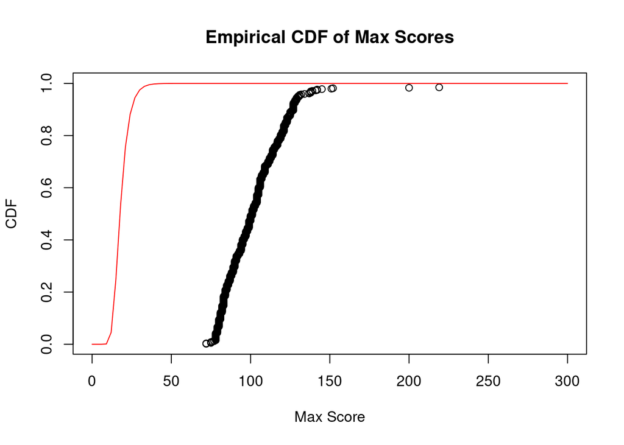

```r
library(ordinal)
# Define the parameters
lambda <- 0.267
K <- 0.041
m <- 1863
n <- 207431389
# Calculate the empirical CDF
scores_sorted <- sort(blast_output$Score)
n <- length(scores_sorted)
ecdf_values <- (1:n) / n
plot(x=scores_sorted, y=ecdf_values, main = "Empirical CDF of Max Scores", xlab = "Max Score", ylab = "CDF", xlim = c(0,300))
# Calculate the parameters for the Gumbel distribution according to Section 5.2.1 of the lecture
a_m <- log(m*K)/lambda
b <- 1/lambda
# Plot the Gumbel distribution
curve(pgumbel(x, loc = a_m, scale = b), add = TRUE, col = "red")
```

```r
# Calculate the p-values (remember that the p-value is the probability to observe a score equal to or larger than S)
p_values <- 1 - pgumbel(scores_sorted, loc = a_m, scale = b)
head(p_values); tail(p_values)
```

```
## [1] 3.420736e-07 3.420736e-07 1.535499e-07 1.535499e-07 1.535499e-07
## [6] 1.175691e-07
```

```
## [1] 0 0 0 0 0 0
```

We can see that the worst alignment in our ranking has a $p$-value of 3.42e-7, which is very low.

# 4 Derive E-values

Since the E-value as it is reported by BLAST is not a probability but the **expected number of alignments exceeding the score *S* just by chance**, we need to find a distribution that models this specific number. This is the Poisson distribution. It looks as follows:

$$\mathbb{P}[N_s = k|y_s] = \frac{e^{-y_s}y^k_s}{k!}$$

The distribution models the probability to have $k$ alignments with score $s$, given the parameter $y_s$, which is the so-called *average rate*. For the BLAST statistics, **$N_s$ is the number of alignments of random sequences with a score equal or higher than $S$ just by chance**. This turns the distributions parameter $y$ into $y_s=Knme^{-\lambda S}$. Since the E-value is the expected number of such alignments, we need to calculate the expectation $\mathbb{E}[N_s]$ of the number of these alignments. For the calculation in order to not be to messy, we stick at first with the $y$ and only replace it later with $Knme^{-\lambda S}$

$$\begin{align}
\mathbb{E}[N_s] &= \sum_{k=0}^{\infty}k\frac{e^{-y_s}y_s^k}{k!} \\
&= 0\frac{e^{-y_s}y_s^0}{0!} +
\sum_{k=1}^{\infty}k\frac{e^{-y_s}y^k_s}{k!} \\
&= \sum_{k=1}^{\infty}\frac{e^{-y_s}y_s^k}{(k-1)!} \\
&= y_se^{-y_s}\sum_{k=1}^{\infty}\frac{y^{k-1}_s}{(k-1)!} \\
&= y_se^{-y_s}\sum_{j=0}^{\infty}\frac{y^{j}_s}{j!} \\
&= y_se^{-y_s}e^{y_s} \\
\mathbb{E}[N_s] &= y_s
\end{align}$$

We just derived that $y_s$ is the expectation $\mathbb{E}[N_s]$ of the distribution. Since $y_s=Knme^{-\lambda S}$, we have $\mathbb{E}[N_s]=Knme^{-\lambda S}=:E$. And this is precisely the definition of the E-value that we want to calculate.

One last thing before we actually calculate the E-values. Usually, as you can see in the first BLAST output above, you do not get the raw alignment score $S$, but the so-called *bit-score* $S'$, which is calculated as follows:

$$S'=\frac{\lambda S-ln(K)}{ln(2)}$$

If we want to compare scores of different alignments, it is important to use $S'$ instead of $S$, because the score of the alignment between query and target sequence depends on the length of the target sequence. Consequentially, the raw alignment scores of two sequences of distinct length are not directly comparable. For that we use the bit-scores of the sequences, as they are comparable between different alignments. Also, you may not always be in the position to get raw alignment scores, but are handed some bit-scores from a colleague that you should process further. Therefore it is important to know what you can do with them.

Using the theoretical framework established above, the parameters from the original BLAST output file and the data we have now ready to be used, we can calculate the bit-scores and E-values and compare our calculations with the values that BLAST provided.

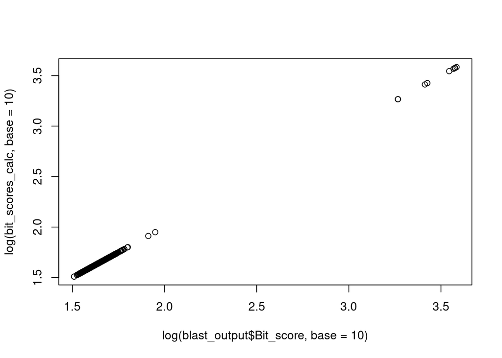

```r
# Define the necessary parameters
l <- 0.267
K <- 0.0410
# Function for the calculation of bis-scores as derived above
bit_score_calc <- function(score, lambda, K){
  bit_score_cal <- round((l*score - log(K))/log(2), digits = 1)
}

bit_scores_calc <- bit_score_calc(score = blast_output$Score, lambda=l, K=K)
# Plot calculated and given scores to check for 1-to-1 correspondence
plot(log(blast_output$Bit_score, base = 10), log(bit_scores_calc, base = 10))
```

```r
# How many score pairs are different from each other?
sum(blast_output$Bit_score != bit_scores_calc)
```

```
## [1] 9
```

```r
# Is this a problem?
blast_output$Bit_score[blast_output$Bit_score != bit_scores_calc]
```

```
## [1] 3844 3773 3757 3699 3504 2667 2587 1849 1845
```

```r
bit_scores_calc[blast_output$Bit_score != bit_scores_calc]
```

```
## [1] 3844.7 3773.4 3757.6 3699.4 3504.5 2667.9 2587.8 1849.7 1845.1
```

Apparently, the scores differ only due to numerical inaccuracy, which is okay.

Now to the E-values. Lets use the bit-scores to calculate them and compare them to the ones provided by BLAST, just as we did before for the bit-scores. Let us first derive the formula to calculate $E$ using $S'$. For that we first express the formula for $S'$ in terms of $K$ and plug this expression for $K$ then into the formula for the E-value $E=Knme^{-\lambda S}$

$$\begin{align}
S'&=\frac{\lambda S-ln(K)}{ln(2)} \\
S'ln(2)&=\lambda S - ln(K) \\
ln(K)&=\lambda S - S' ln(2) \\
exp(ln(K)) &= exp(\lambda S - S' ln(2)) \\
K &= e^{\lambda S - S' ln(2)} = e^{\lambda S} e^{-S' ln(2)}
\\
&= e^{\lambda S} (e^{ln(2)})^{-S'} \\
&= e^{\lambda S} 2^{-S'}
\end{align}$$

Plugging now $K = e^{\lambda S} 2^{-S'}$ into $E=Knme^{-\lambda S}$, we get the following equation:

$$\begin{align}
E &= Knme^{-\lambda S} \\
&= e^{\lambda S} 2^{-S'} nme^{-\lambda S} \\
&= e^{\lambda S}e^{-\lambda S} nm2^{-S'} \\
E &= nm2^{-S'}
\end{align}$$

This is it. Here we have an equation that only needs the database length $n$, the query sequence length $m$ and the bit-score $S'$ to calculate the E-value $E$. Now we just need to write a simple *R* function to implement this equation:

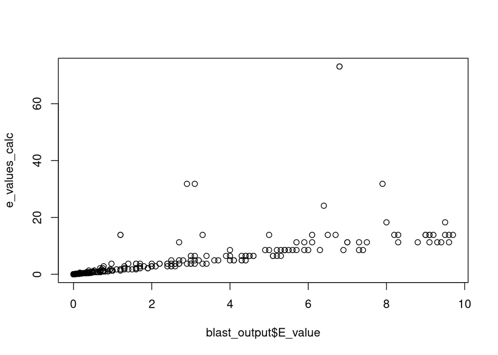

```r
# Define the parameters
lambda <- 0.267
K <- 0.041
m <- 1863
n <- 207431389

# Function for the calculation of E-values from bit-scores
e_value_calc <- function(bit_score, m, n){
  bit_score_cal <- round(m*n*(2^(-bit_score)), digits = 2)
}

e_values_calc <- e_value_calc(bit_score = bit_scores_calc, m=m, n=n)
# Plot calculated and given scores to check for 1-to-1 correspondence
plot(blast_output$E_value, e_values_calc)
```

What happened here? Some of our calculated E-values do not fit at all to the ones obtained from BLAST. Lets get to the bottom of this. We might learn something valuable on the way!

```r
# Correlation coefficient between calculated and BLAST E-values
cor(e_values_calc, blast_output$E_value) # 0.80
```

```
## [1] 0.7045111
```

```r
# Calculate the distance between calculated and BLAST E-values
dists <- abs(e_values_calc - blast_output$E_value)
mean(dists) # 0.994
```

```
## [1] 0.9988382
```

```r
sum(dists>1) # 103
```

```
## [1] 104
```

```r
sum(dists<=1) # 491
```

```
## [1] 489
```

```r
sum(dists>10) # 10
```

```
## [1] 10
```

```r
# Extract those rows whose calc. E-values differ the most from the BLAST E-values
blast_e_sub <-  blast_output[dists > 10,]
blast_e_sub["E_values_calc"] <- e_values_calc[dists > 10]
blast_e_sub
```

```
##              Accession_ID Alignment_length Percent_identity Gaps_number Score
## 463 sp|Q9CPX9|APC11_MOUSE               45           31.111           8    78
## 464 sp|Q3ZCF6|APC11_BOVIN               45           31.111           8    78
## 509 sp|Q9M9L0|APC11_ARATH               29           34.483           0    75
## 513 sp|Q54L48|APC11_DICDI               34           41.176           1    75
## 518 sp|Q9P0P0|RN181_HUMAN               60           31.667           6    78
## 563   sp|Q6AXU4|RN181_RAT               60           30.000           6    76
## 566 sp|Q5R8A2|APC11_PONAB               45           28.889           8    72
## 567 sp|Q9NYG5|APC11_HUMAN               45           28.889           8    72
## 575 sp|Q7ZW78|RN181_DANRE               52           34.615           6    75
## 576 sp|Q8CEF8|RN222_MOUSE               73           27.397          12    77
##     Bit_score E_value E_values_calc
## 463      34.7     1.2         13.85
## 464      34.7     1.2         13.85
## 509      33.5     2.9         31.81
## 513      33.5     3.1         31.81
## 518      34.7     3.3         13.85
## 563      33.9     6.4         24.11
## 566      32.3     6.8         73.08
## 567      32.3     6.8         73.08
## 575      33.5     7.9         31.81
## 576      34.3     8.0         18.27
```

One thing we already notice is that the largest differences between our calculated E-values and the ones coming from BLAST occurs for alignments with rather low score. In the lecture you learned that the equation $\mathbb{P}[M\leq x] = exp(-e^{-\lambda(x-u)})$ only holds for x being big enough, namely for approximately $x \geq ln(mn)/\lambda$. Since we already have the parameters $n$, $m$ and $\lambda$, let us see how large $x$ should be at least in order to make the whole statistical theory sound:

$$\begin{align}
x &= \frac{ln(mn)}{\lambda} \\
&= \frac{ln(1863\times 207431389)}{0.267} \\
&\approx 100
\end{align}$$

What help is this value for $x$? Recall that before, we just replaced $x$ by our score $S$ to get to the equation $\mathbb{P}[M > S] = 1 - \mathbb{P}[M\leq S] = 1 - exp(-Knme^{-\lambda S})$. This puts a lower bound of approximately 100 on our score $S$ that we can use to calculate E-values. So how many alignment scores do we have that are actually lower than 100?

```r
# Total number of scores smaller than 100
sum(blast_output$Score <= 100)
```

```
## [1] 292
```

```r
# Fraction of all scores lower than 100
sum(blast_output$Score <= 100)/nrow(blast_output)
```

```
## [1] 0.4924115
```

We see that close to half of the alignments from our BLAST search have a score $\leq 100$. Maybe they are also those alignments for which our calculated E-values differ a lot from the ones given by BLAST. To check that, lets add the calculated E-values and bit-scores to our dataframe. We will also create a binary column indicating which alignment scores are larger 100 for some visualizations and statistics.

```r
library("tidyverse")
```

[output not shown]

```r
blast_output["E_values_calc"] <- e_values_calc
# Create a binary variable indicating whether S >= ln(m*n)/lambda
blast_output["Score_bigger_100"] <- blast_output["Score"] > 100
```

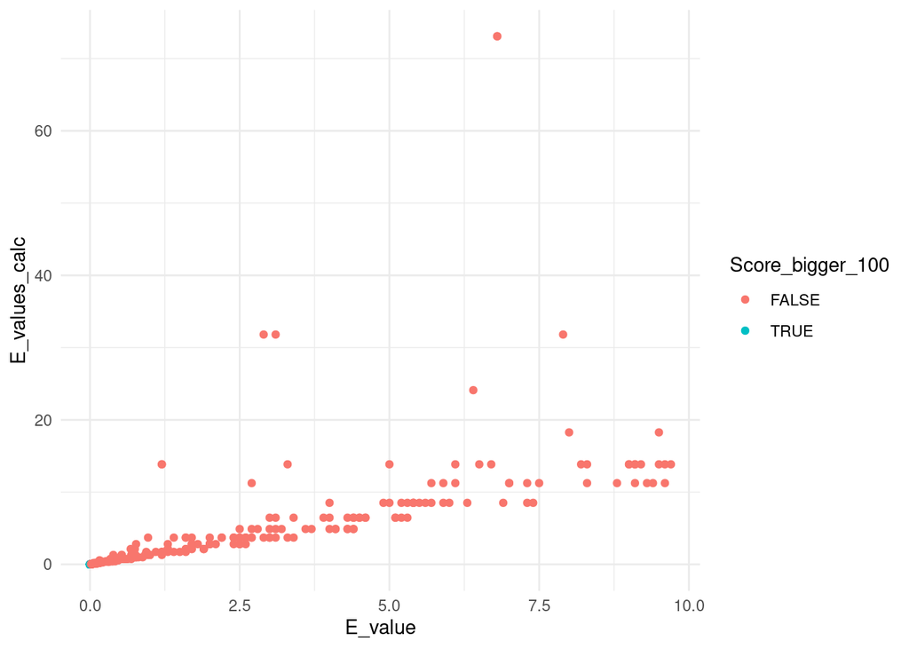

```r
ggplot(blast_output, aes(x=E_value, y=E_values_calc)) +
  geom_point(mapping = aes(color = Score_bigger_100)) +
  theme_minimal()
```

Although it looks like most alignments have scores $<100$, this is not true. It is just the case that the E-values of half the dataset are crammed in the lower left corner. If you take a close look you can see that there is some blue color. We will zoom in a little to get a closer look at that region:

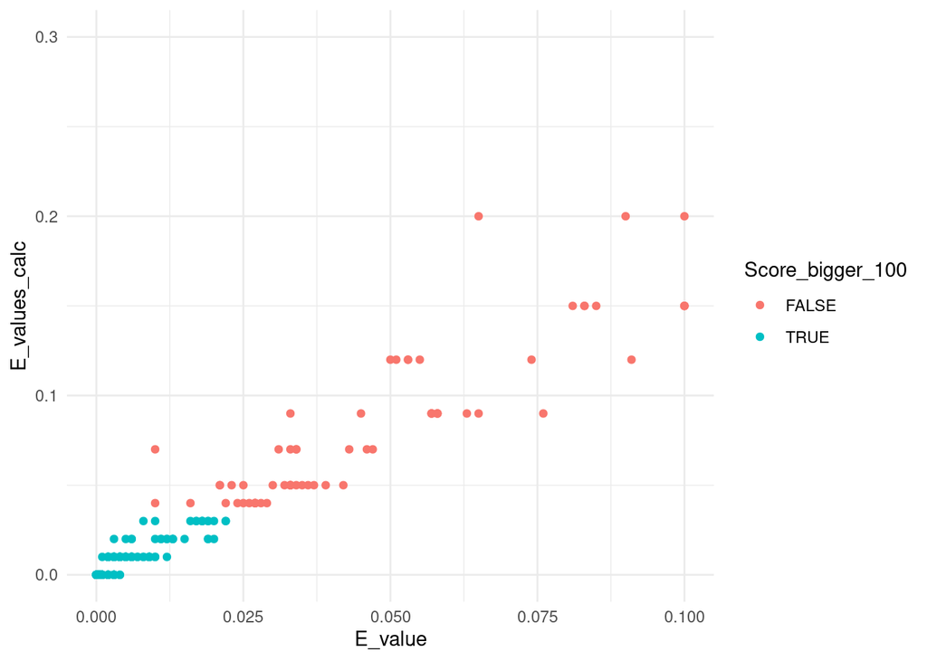

```r
ggplot(blast_output, aes(x=E_value, y=E_values_calc)) +
  geom_point(mapping = aes(color = Score_bigger_100)) +
  xlim(0,0.1) +
  ylim(0,0.3) +
  theme_minimal()
```

Now we see the following. Although we systematically overestimated the E-values by some degree, we can see that there are almost no outliers in our calculated E-values for very low E-values from BLAST. We will refine this soon. Finally, lets calculate the relative distance between calculated and BLAST E-value for the alignments, but this time separated by the binary score value we created:

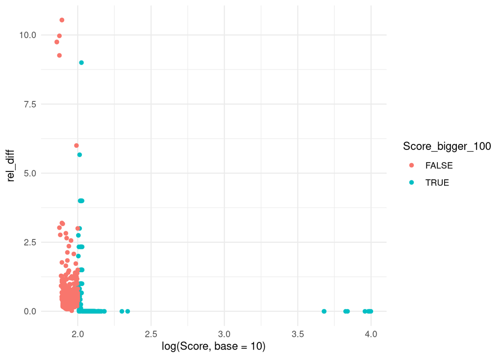

```r
# If any one of the two E-values is 0, the error is equal to the other E-value. Otherwise it is the absolute difference divided by the BLAST E-value
blast_output["rel_diff"] <- case_when(blast_output$E_value == 0 ~ blast_output$E_values_calc,
                                      blast_output$E_values_calc == 0 ~ blast_output$E_value,
                                      TRUE ~ abs((blast_output$E_value - blast_output$E_values_calc))/blast_output$E_value)

ggplot(blast_output, aes(x=log(Score, base=10), y=rel_diff)) +
  geom_point(mapping = aes(color = Score_bigger_100)) +
  theme_minimal()
```

Although we are already dealing with logarithmized values, it looks still very cramped on the left side. Lets again zoom in a little:

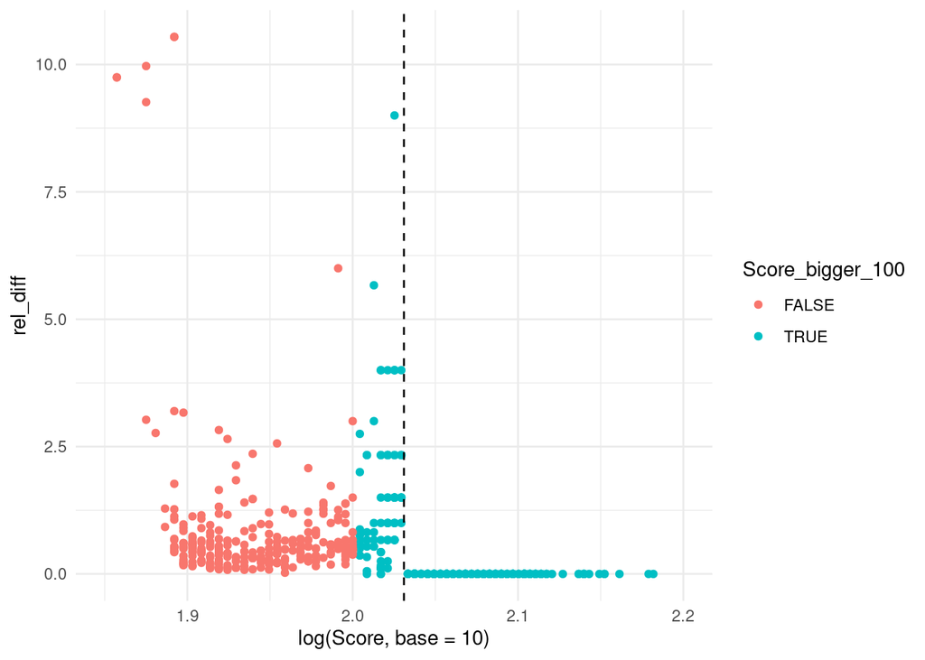

```r
ggplot(blast_output, aes(x=log(Score, base=10), y=rel_diff)) +
  geom_point(mapping = aes(color = Score_bigger_100)) +
  xlim(1.85,2.2) +
  geom_vline(xintercept = 2.031, linetype="dashed") +
  theme_minimal()
```

Now this is some valuable information. We see that for scores below $10^{2.031} = 107.4$, we get a few rather large relative errors. However, after that point, no calculation differs a lot from the BLAST E-value. This we already saw in the previous plot. Using this heuristic boundary of $10^{2.031} = 107.4$, we could filter our BLAST output for sequences with reliable score. So if we were to trust the E-values, we should do so only for alignments with score $S \geq 107.4$. This should be a valuable lesson you better not forget. Whenever you are working with statistical methods of any kind, it is paramount to check whether the assumptions your method demands are actually met by the data. Otherwise the statistical analysis may be entirely worthless!

There might also be another source of error in our calculations. The formula $E=Kmne^{-\lambda S}$ can be found on virtually any website and in every tutorial concerning BLAST, where we have discussed $m$ and $n$ before. For alignments that start near the end of either sequence, however, it may happen that the alignment runs out of sequence before achieving a significant score. In order to make the equation for $E$ more accurate, the sizes $m$ and $n$ are altered for alignments that start to close to the end of the sequence. You can find the algorithm used for the correction at https://bmcresnotes.biomedcentral.com/articles/10.1186/1756-0500-5-286.

# 5 Take home messages for BLAST

- E-values are a tricky thing. Depending on the task, the threshold to choose for subsequent analyses can vary vastly. Here, we included not only ortholog sequences, but also homolog sequences that share only partial sequence similarity. Did we want to include these sequences? Sometimes it es necessary to go back a few steps in your analysis and repeat some of the steps making better informed choices.
- Since the calculation of the bit-scores as well as the E-values depends on the size of the database, it would be a good idea to think about the database you want to use for your problem **before running the analysis**. Two alignments with identical target and query sequences can have very different E-values, if the databases used for the alignments were of different sizes. It is not always smart to use the largest database available, if you wish to only search in specific data e.g. human sequences.
- Nucleotide sequences diverge faster than protein sequences, due to redundancy in the genetic code. The right version of BLAST (e.g. BLASTN, TBLASTN, etc.) should be used for each kind of sequence.
- An appropriate scoring matrix should be used. Here, we used the default BLOSUM62, however, for long evolutionary timescales, e.g. PAM250 would be more appropriate. Different research questions demand different substitution matrices, so it is important to think about the kind of matrix you should employ in order to conduct good science.